# MATH-156 - Inference for One-Sample Quantitative Data

**Directions**:

- As always, the expectation is that you thoughtfully work through this activity with a partner, discussing the embedded questions and recording your responses in a shared document
  - We will pause every 10ish minutes to go over certain questions as a class, you are expected to revise your write-up to update any responses that are inaccurate based upon these discussions
  - At times you will be asked to add screenshots to your write-up. If you are on a Windows PC, an easy way to do this is the “snipping tool”, which you can find using the search bar along the bottom of your screen. If you are on a Mac, you can find instructions on [how to take a screenshot at this link](https://support.apple.com/en-us/HT201361).
- Both you and your partner should upload your write-up to Canvas after class
  - Depending on our conversations you might not have time to finish all the questions in class - that’s okay and you don’t need to do them on your own. Your grade on these write-ups will be based upon whether you worked diligently during class. Accuracy will only count on one or two key questions (which will not be disclosed ahead of time, but will be early enough that you will have completed them if you were working at an appropriate pace)
- With that said, please do not try and rush through the questions, the purpose of these activities is to learn the material, not to hurriedly complete all the questions

$~$

## Application #1 - Wetsuits and the Olympics

At the 2008 Beijing Olympics, 25 world records in swimming were broken, the most new records since 1976 - the first year goggles were used.

Of these 25 new records, 23 were set by swimmers who wore a new, *scientifically designed swimsuit* named the *LZR Racer*. Speedo, producer of the LZR Racer, went so far as to collaborate with NASA scientists on the wetsuit’s design.

Not surprisingly, these new suits led to an existential crisis in swimming. Many believed that swimmers who couldn’t access these new suits would be non-competitive. By 2010, the controversy had reached the point where FINA (the governing body of professional swimming) [banned all swimsuits that “aids speed, bouyancy, or performance”](https://www.nytimes.com/2009/07/25/sports/25swim.html).

Shown below is an infographic describing the LZR Racer in greater detail:

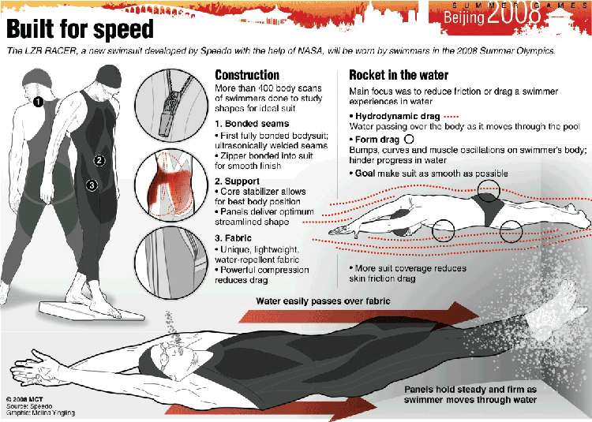

$~$

**Question #1**: Consider the argument that “In 2008, 23 of the 25 new records involved the new swimsuit, therefore the suit must improve swimming performance”. Can you think of any alternative explanations for why 23 of 25 records might have been achieved by swimmers wearing the LZR Racer? How would you design a study that might be more convincing (from a statistician’s perspective)?

$~$

### An Experimental Study

To investigate whether swimsuits like the LZR Racer truly improve performance, researchers recruited 12 individuals with professional swimming experience (either triathletes or swimmers) and had each swim 1500m for time, under two conditions:

1. wearing a scientifically designed wetsuit akin to the LZR Racer
2. wearing a control suit that looked similar to the scientifically designed suit but did not use any new materials or technologies

The order of these two swims was randomized, and the outcome of interest was the difference in swim velocities (m/s) across the two 1500m swims (Wetsuit velocity - Control velocity). The data are shown below:

| Wetsuit | Control | Difference | Gender | Category |
| --- | --- | --- | --- | --- |
| 1.57 | 1.49 | 0.08 | F | swimmer |
| 1.47 | 1.37 | 0.10 | F | triathlete |
| 1.42 | 1.35 | 0.07 | F | swimmer |
| 1.35 | 1.27 | 0.08 | F | triathlete |
| 1.22 | 1.12 | 0.10 | M | triathlete |
| 1.75 | 1.64 | 0.11 | M | swimmer |
| 1.64 | 1.59 | 0.05 | M | swimmer |
| 1.57 | 1.52 | 0.05 | M | triathlete |
| 1.56 | 1.50 | 0.06 | M | triathlete |
| 1.53 | 1.45 | 0.08 | M | triathlete |
| 1.49 | 1.44 | 0.05 | M | triathlete |
| 1.51 | 1.41 | 0.10 | M | triathlete |

**Question #2**: Notice *every* participant swam faster when wearing the wetsuit. Do you think that these results could be explained by *flaws in the design of the study*? Briefly explain, be sure to address the possibility of concerns related to sampling, confounding, and bias in your answer.

$~$

### Checking Assumptions

Recall that statistical inference using the $t$-distribution is appropriate in two situations:

1. The sample size is small, but the population that was sampled is Normally distributed
2. The sample size is relatively large ($n \geq 30$), regardless of how the population is distributed

**Question #3**: The boxplot below summarizes the distribution of changes in swim velocity (Wetsuit - Control Suit) for the 12 participants in this study. The “X” represents the sample mean. Based upon all of the available information, do you believe it is appropriate to use the $t$-distribution when analyzing these data? Briefly explain.

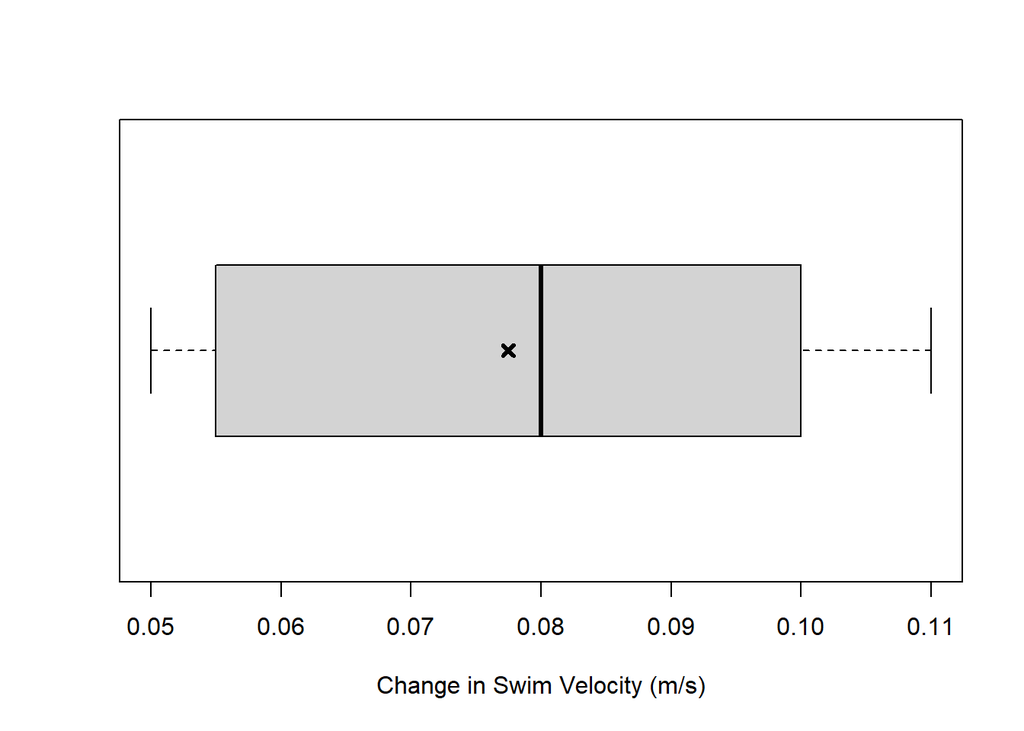

$~$

### Hypothesis Testing

**Question #4**: Use these data to evaluate the hypothesis that the new wetsuit technology has no impact on a swimmer’s performance. When conducting your test, be sure to perform the following steps:

1. State the Null Hypothesis in words and mathematical symbols
2. Calculate an appropriate $Z$ or $T$ value
3. Translate the $Z$ or $T$ value into a $p$-value
4. Use the $p$-value to make a one-sentence conclusion regarding the plausibility of the Null Hypothesis

*Note*: You can use [this online calculator](https://www.calculator.net/statistics-calculator.html), or [StatKey](https://www.lock5stat.com/StatKey/descriptive_1_quant/descriptive_1_quant.html), to find the sample mean and sample standard deviation of these data (pasted for your convenience: `.08, .1, .07, .08, .1, .11, .05, .05, .06, .08, .05, .1`). Be sure you are using the *sample standard deviation*.

$~$

### Reporting an Effect Size

The hypothesis test you conducted in Question #4 indicates there is a statistically significant advantage to using the new wetsuit technology, but is that difference practically meaningful? In this section we will explore that question.

**Question #5**: Briefly explain the difference between *statistical significance* and *clinical (practical) significance* in this application. That is, in your own words, what would it mean for the new wetsuit technology to offer a *statistically significant* advantage, but not a *clinically significant* advantage?

**Question #6**: Recall that confidence intervals provide a statistical method for evaluating the clinical significance of an observed outcome. Use these data to come up with a 95% confidence interval estimate for the mean improvement in 1500m swim velocity (in competitive swimmers).

**Question #7**: In this study, swimmers had 1500m swim velocities ranging from 1.12 to 1.64 (with an average of 1.43 m/s) when not using the new wetsuit technology. Based upon this information, do you think the results of this study are clinically significant? Briefly explain.

$~$

## Application #2 - Sleep Deprivation

It is well-established that sleep deprivation has a detrimental cognitive effects. But do these effects linger, or can a person “make up” for sleep deprivation by getting a full night’s sleep for consecutive days?

An article published in *Nature* ([Stickgold, James, and Hobson, 2000](https://www.nature.com/articles/nn1200_1237)) had 11 volunteers, aged 18 to 25, perform a visual discrimination task on two separate occasions. The first task was performed immediately following a night of deprived sleep, and the second task was performed after two nights where the participants could sleep as much they wanted.

In each task, subjects were repeatedly shown screens containing a *fixation letter* (either T or L) and *three bars* (either oriented horizontally or vertically) in a random configuration (sometimes the letter was T/L and sometimes the bars were horizontal/vertical). The researchers recorded the time it took each subject to correctly identify the fixation letter and the orientation of the bars. In between each screen, a masking screen was flashed.

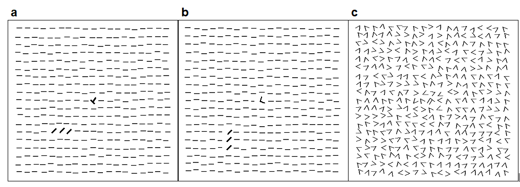

The figure above illustrates two possible *target screens* (a) and (b), as well as a *masking screen* (c). In target screen (a), a correct response would be “T” and “horizontal”; while in target screen (b), a correct response would be L and “vertical”, The masking screen (c) would briefly appear between randomized target screens.

Each subject saw 1250 randomly determined trial screens (in blocks of 25) on each repeat of the test (after a night of sleep deprivation, then after two nights of full sleep). The differences in performance (measured as the average response time in milliseconds) for each subject are shown below, with positive values indicating faster responses the second time they took the test.

| Subject | Improvement |
| --- | --- |
| 1 | -14.7 |
| 2 | -10.7 |
| 3 | -10.6 |
| 4 | 2.2 |
| 5 | 2.4 |
| 6 | 4.5 |
| 7 | 7.2 |
| 8 | 9.6 |
| 9 | 10.0 |
| 10 | 21.3 |
| 11 | 21.8 |

**Question #8**: Inspecting the data, it appears that most subjects responded more quickly on the second test (after getting two nights of sleep). Come up with *at least three* possible explanations for the observed improvement? How would you classify each explanation (in statistical terms)?

$~$

### Checking Assumptions

The boxplot below displays the distribution of these 11 data-points, with the mean improvement denoted by the “X”:

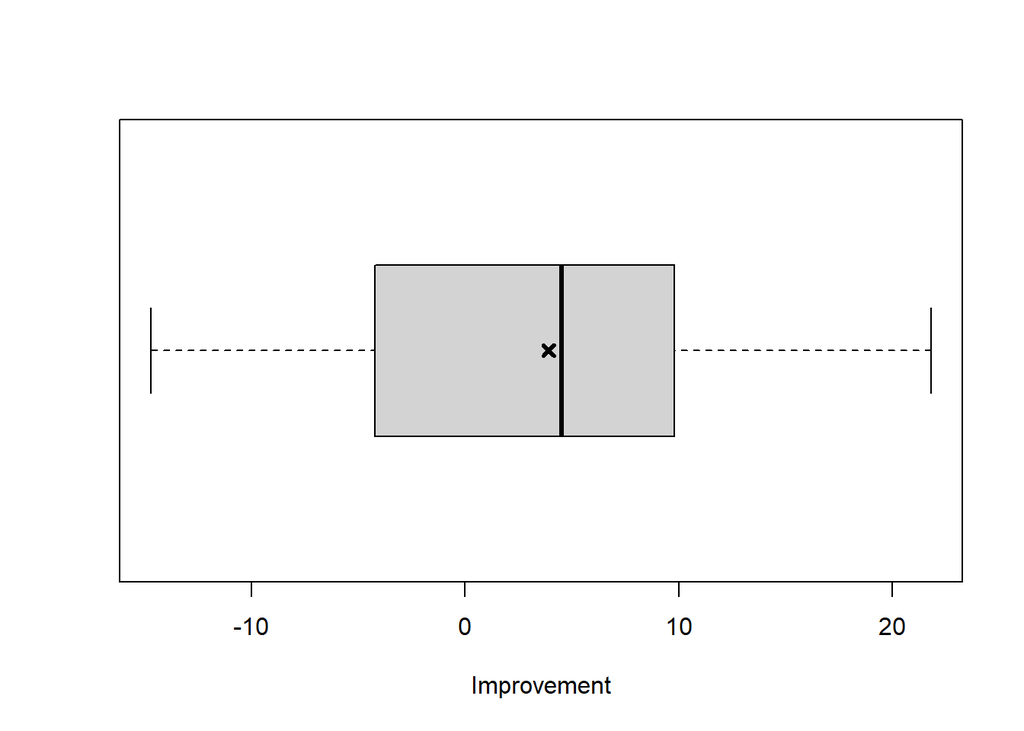

**Question #9**: Based upon what you’ve seen, do you believe the $t$-distribution can be used for statistical inference on these data?

$~$

### The Role of Random Chance

In this experiment, the mean improvement of the 11 subjects was 3.9 milliseconds and the standard deviation of these improvements was 12.2 milliseconds.

**Question #10**: Conduct a $T$-test to evaluate whether it is possible that this improvement might be due to random chance. Be sure to include the following:

1. State the null hypothesis in both words and statistical symbols
2. Show how you calculated the $T$-value
3. Provide the $p$-value
4. Provide a one-sentence conclusion *in the context of this application*

$~$

### Reflecting

A major weakness of our analysis of these data is that it ignores the possibility that improvements are due to subjects taking the test for the second time, thereby making it more familiar and less challenging. The researchers in the real study anticipated this, and used a *control group* containing 10 subjects (who did both the first and second tasks without sleep deprivation). The boxplots below illustrate the results in these two groups:

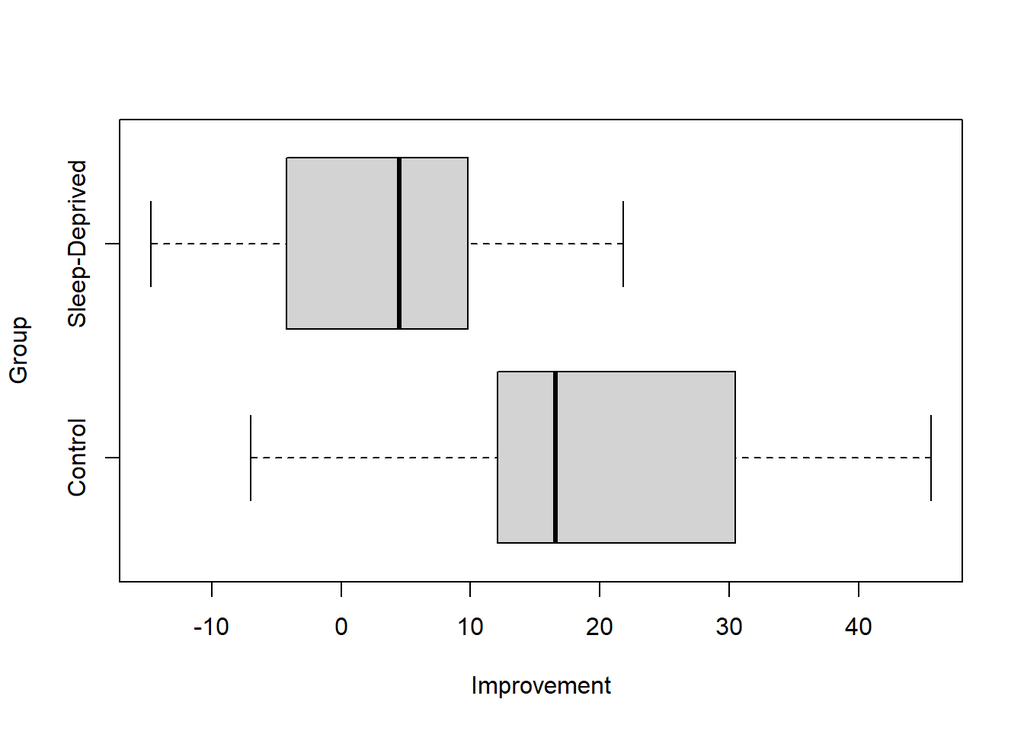

**Question #11**: How do the results in the control group influence your assessment of the data? That is, do you still care about the hypotheses/explanations you considered in Questions 1-3 of this application? Briefly explain.